# TP Statistique

BOUZID Kenza

29 mars 2020

set.seed(287)

Voici le plan de ce qui sera fait dans le TP.

# 0. Visualisation de chemins

Lecture du fichier des villes :

```r
villes <- read.csv('DonneesGPSvilles.csv',header=TRUE,dec='.',sep=';',quote="\"")
str(villes)
```

```
## 'data.frame':    22 obs. of  5 variables:
##  $ EU_circo : Factor w/ 7 levels "ÃŽle-de-France",..: 6 6 4 3 7 4 3 2 3 4 ...
##  $ region   : Factor w/ 22 levels "Alsace","Aquitaine",..: 22 10 19 11 2 5 9 3 6 17 ...
##  $ ville    : Factor w/ 22 levels "Ajaccio","Amiens",..: 11 1 2 3 4 5 6 7 8 9 ...
##  $ latitude : num  45.7 41.9 49.9 47.2 44.8 ...
##  $ longitude: num  4.847 8.733 2.3 6.033 -0.567 ...
```

Représentation des chemins par plus proches voisins et du chemin optimal :

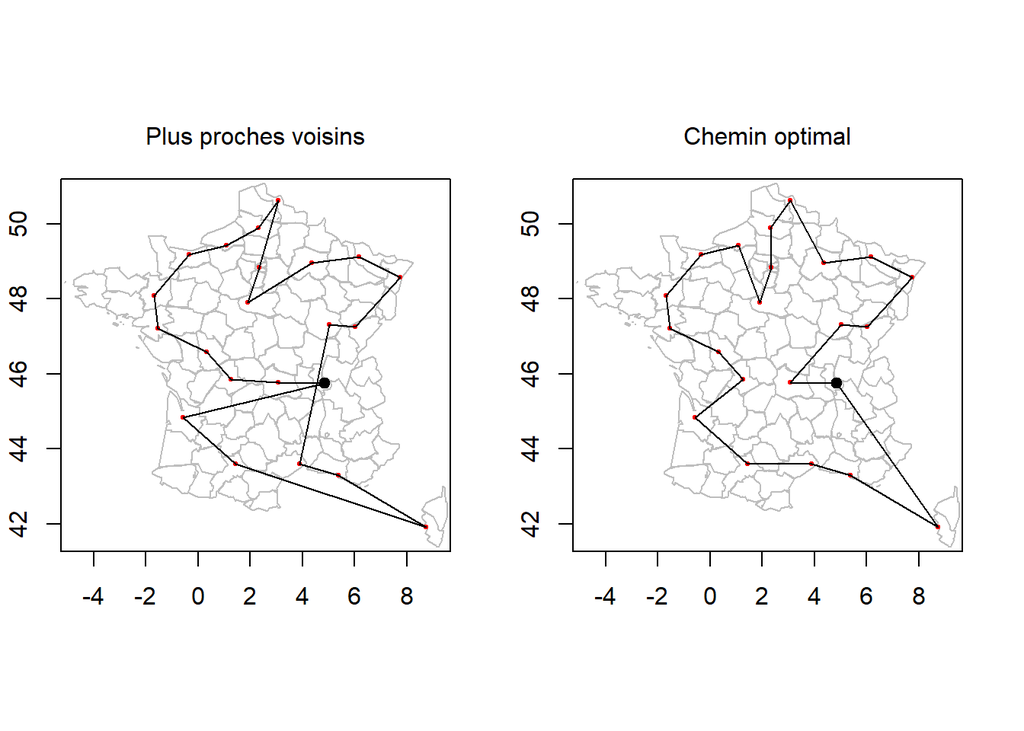

```r
coord <- cbind(villes$longitude,villes$latitude)
dist <- distanceGPS(coord)
voisins <- TSPnearest(dist)

pathOpt <- c(1,8,9,4,21,13,7,10,3,17,16,20,6,19,15,18,11,5,22,14,12,2)

par(mfrow=c(1,2),mar=c(1,1,2,1))
plotTrace(coord[voisins$chemin,], title='Plus proches voisins')
plotTrace(coord[pathOpt,], title='Chemin optimal')
```

Les longueurs des trajets (à vol d’oiseau) valent respectivement, pour la méthode des plus proches voisins :

```
## [1] 4303.568
```

et pour la méthode optimale :

```
## [1] 3793.06
```

Ceci illustre bien l’intérêt d’un algorithme de voyageur de commerce. Nous allons dans la suite étudier les performances de cet algorithme.

# 1. Comparaison d’algorithmes

Nombre de sommets fixes et graphes “identiques”.

```r
      n <- 10
sommets <- data.frame(x = runif(n), y = runif(n))
  couts <- distance(sommets)
```

## 1.2. Temps de calcul

Comparaison des temps à l’aide du package microbenchmark.

Exemple d’application de microbenchmark :

```r
microbenchmark(sqrt(x),x^0.5, times=100, setup={x <- runif(1)})
```

[output not shown]

[output cut: 190 more lines]

# 2. Etude e la complexité de l’algorithme Branch and Bound

## 2.1. Comportement par rapport au nombre de sommets : premier modèle

- pertinence des coefficients et du modèle,
- étude des hypothèses sur les résidus.

## 2.2. Comportement par rapport au nombre de sommets : étude du comportement moyen

- pertinence des coefficients et du modèle,
- étude des hypothèses sur les résidus.

## 2.3. Comportement par rapport à la structure du graphe

- pertinence des coefficients et du modèle,
- étude des hypothèses sur les résidus.